# Proyecto 1

Juan De Leon, Maria Jose Castro, Jose Block

5/4/2021

# Analisis Exlporatorio

## Situación Problemática

En Guatemala se tiene uno de los índices de desnutrición infantil más altos de latinoamérica, al mismo tiempo que se tiene una muy baja tasa de alfabetización. También es bien conocido que el sistema de salud del país es muy precario y la mayoría de personas del interior del país no tienen acceso ni a un centro de salud o control natal, también la mayoría de los partos se dan con comadronas y no en centros asistidos por un médico.

Desde esta perspectiva de los dos puntos dos datos anteriores parece que como país no se brindan las condiciones y oportunidades necesarias para poder permitir florecer a la niñez.

Lo que buscamos con el siguiente trabajo es poder identificar cuáles son algunos de los factores más influyentes en los nacimientos y poder identificar patrones para plantear soluciones. Desde la búsqueda por departamentos, información que se pueda obtener de la madre, edades, etc.

Con identificar esto buscamos determinar el departamento en mayor necesidad de educación sexual, centros asistenciales, control prenatal, etc. En Guatemala pasa que al hacer inversiones en ciertas áreas como la educación, se hace la inversión sin pensar en qué sectores es más eficiente invertir en educación y resulta ser una inversión con un bajo impacto en el país, porque resulta que hay sectores que lo necesitan.

## Problema científico

Como segundo objetivo ya mencionado será identificar las condiciones de cada parto y las más comunes según el departamento.

## Objetivos

- Determinar cuales son las variables más influyentes o repetitivas en que una madre sea soltera por medio de un modelo.
- Identificar la correlación (si es que existe) entre el departamento con mayor tasa de nacimientos y predecir como esta aumentará.
- Determinar los departamentos en los que más se debe invertir en educación sexual según los índices obtenidos.
- Realizar hallazgos para posibles analisis de el set de datos explorado.

## Descripción de los datos

Para el desarrollo de este proyecto se trabajó con la base de datos de [Estadísticas Vitales](https://www.ine.gob.gt/ine/vitales/) del Instituto Nacional de Estadística de Guatemala (INE) desde el año 2010 al año 2019. Estas estadísticas provienen de registros administrativos de nacimientos, defunciones, matrimonios y divorcios. Las estadísticas vitales brindan información importante sobre los cambios de patrones en las áreas antes mencionadas, brindando así, una visión dinámica de la población.

Dado que esta información está en archivos .xls el paso inicial que tomo el grupo fue juntar todos los sets de datos en un solo data frame por hoja que cada archivo contiene. Dado que se trabajo con información de 10 años distintos no en todos se cuantifica la misma información, por lo que fue necesario excluir ciertos datos que en archivos recientes si hay. Se agrego una columna a cada data frame para diferenciar el año en el que se obtuvo esa información. Seguido de esto se guardaron todos los data frames, habiendo unido la informacion de los 10 archivos distintos, en un archivo .RData.

Luego de juntar los sets de datos se clasifico cuales iban a ser relevantes para solventar la problemática anteriormente planteada. Por lo que se escogieron los siguientes sets de datos:

- Nacimientos por departamento de residencia de la madre, según edades simples de la madre
- Nacimientos por estado civil de la madre, según departamento de su residencia
- Nacimientos por estado civil de la madre, según grupos de edad
- Nacimientos por grupos de edad de la madre, según grupos de edad del padre
- Número de hijos(as) tenidos, según edades simples de la madre
- Nacimientos por grupos de edad de la madre, según departamento y municipio de su residencia
- Nacimientos por grupos de edad de la madre, según grandes grupos ocupacionales de la madre
- Nacimientos por edad de la madre, según departamento de residencia, área geográfica de ocurrencia, y grupo étnico de la madre
- Nacimientos por escolaridad de la madre, según número de hijos(as) tenidos

A continuación, mostramos una clasificación de las variables por cada set de datos:

- Nacimientos por departamento de residencia de la madre, según edades simples de la madre
  - Edad: variable cuantitativa discreta.
  - Departamento: Variable cualitativa nominal

```
##   rows columns discrete_columns continuous_columns all_missing_columns
## 1  506      26                1                 25                   0
##   total_missing_values complete_rows total_observations memory_usage
## 1                    0           506              13156       114136
```

- Nacimientos por departamento de residencia de la madre, segun departamento de ocurrencia
  - Mes: Variable cualitativa ordinal
  - Departamento: Variable cualitativa nominal
  - Total: Cuantitativa discreta
  - Hombres: Cuantitativa discreta
  - Mujeres: Cuantitativa discreta
  - Año: Cuantitativa discreta

```
##   rows columns discrete_columns continuous_columns all_missing_columns
## 1 2880       5                2                  3                   0
##   total_missing_values complete_rows total_observations memory_usage
## 1                    0          2880              14400       119336
```

- Nacimientos por estado civil de la madre, según departamento de su residencia
  - Departamento: Variable cualitativa nominal
  - Estado Civil: Variable cualitativa nominal

```
##   rows columns discrete_columns continuous_columns all_missing_columns
## 1  240       6                1                  5                   0
##   total_missing_values complete_rows total_observations memory_usage
## 1                    0           240               1440        15136
```

- Nacimientos por estado civil de la madre, según grupos de edad
  - Grupo de Edad: Variable cuantitativa discreta
  - Estado Civil: Variable cualitativa nominal

```
##   rows columns discrete_columns continuous_columns all_missing_columns
## 1  100       6                1                  5                   0
##   total_missing_values complete_rows total_observations memory_usage
## 1                    0           100                600         7608
```

- Nacimientos por grupos de edad de la madre, según grupos de edad del padre
  - Grupo de Edad Madre: Variable cuantitativa discreta
  - Grupo de Edad Padre: Variable cuantitativa discreta
- Número de hijos(as) tenidos, según edades simples de la madre
  - Edad: Variable cuantitativa discreta
  - Numero de Hijos: Variable cuantitativa discreta
- Nacimientos por grupos de edad de la madre, según departamento y municipio de su residencia
  - Departamento: Variable cualitativa nominal
  - Municipio: Variable cualitativa nominal
  - Grupo de Edad: Variable cuantitativa discreta

```
##   rows columns discrete_columns continuous_columns all_missing_columns
## 1 3393      13                2                 11                   0
##   total_missing_values complete_rows total_observations memory_usage
## 1                    0          3393              44109       380856
```

- Nacimientos por grupos de edad de la madre, según grandes grupos ocupacionales de la madre
  - Grupos Ocupacionales: Variable cualitativa nominal
  - Grupo de Edad: Variable cuantitativa discreta

```
##   rows columns discrete_columns continuous_columns all_missing_columns
## 1  129      12                1                 11                   0
##   total_missing_values complete_rows total_observations memory_usage
## 1                    0           129               1548        17336
```

- Nacimientos por edad de la madre, según departamento de residencia, área geográfica de ocurrencia, y grupo étnico de la madre
  - Departamento: Variable cualitativa nominal
  - Area Geografica: Variable cualitativa nominal
  - Grupo Etnico: Variable cualitativa nominal
  - Grupo de Edad: Variable cuantitativa discreta

```
##   rows columns discrete_columns continuous_columns all_missing_columns
## 1 1800      13                2                 11                   0
##   total_missing_values complete_rows total_observations memory_usage
## 1                   20          1798              23400       193576
```

- Nacimientos por escolaridad de la madre, según número de hijos(as) tenidos
  - Numero de hijos: variable cuantitativa discreta
  - Escolaridad de la madre: varibale cualitativa nominal

```
##   rows columns discrete_columns continuous_columns all_missing_columns
## 1  184      10                1                  9                   0
##   total_missing_values complete_rows total_observations memory_usage
## 1                    0           184               1840        18888
```

Tambien se revisó que la mayoría de variables no tubieran duplicados por tíldes, principalmente en la columnas de departamentos y mucicipios.

```
## [1] "dpto_res_ocu"
```

```
##  [1] "Todos los departamentos" "Guatemala"
##  [3] "El Progreso"             "Sacatepéquez"
##  [5] "Chimaltenango"           "Escuintla"
##  [7] "Santa Rosa"              "Sololá"
##  [9] "Totonicapán"             "Quetzaltenango"
## [11] "Suchitepéquez"           "Retalhuleu"
## [13] "San Marcos"              "Huehuetenango"
## [15] "Quiché"                  "Baja Verapaz"
## [17] "Alta Verapaz"            "Petén"
## [19] "Izabal"                  "Zacapa"
## [21] "Chiquimula"              "Jalapa"
## [23] "Jutiapa"
```

```
## [1] "nac_edad_madre_departamento_municipio"
```

```
##  [1] "Todos los departamentos" "Guatemala"
##  [3] "El Progreso"             "Sacatepéquez"
##  [5] "Chimaltenango"           "Escuintla"
##  [7] "Santa Rosa"              "Sololá"
##  [9] "Totonicapán"             "Quetzaltenango"
## [11] "Suchitepéquez"           "Retalhuleu"
## [13] "San Marcos"              "Huehuetenango"
## [15] "Quiché"                  "Baja Verapaz"
## [17] "Alta Verapaz"            "Petén"
## [19] "Izabal"                  "Zacapa"
## [21] "Chiquimula"              "Jalapa"
## [23] "Jutiapa"                 "Extranjero"
## [25] "Ignorado"
```

```
## [1] "nac_depto_sexo_peso"
```

```
##  [1] "Todos los departamentos" "Guatemala"
##  [3] "El Progreso"             "Sacatepéquez"
##  [5] "Chimaltenango"           "Escuintla"
##  [7] "Santa Rosa"              "Sololá"
##  [9] "Totonicapán"             "Quetzaltenango"
## [11] "Suchitepéquez"           "Retalhuleu"
## [13] "San Marcos"              "Huehuetenango"
## [15] "Quiché"                  "Baja Verapaz"
## [17] "Alta Verapaz"            "Petén"
## [19] "Izabal"                  "Zacapa"
## [21] "Chiquimula"              "Jalapa"
## [23] "Jutiapa"                 "Extranjero"
## [25] "Ignorado"
```

```
## [1] "nac_por_estado_civil"
```

```
##  [1] "Todos los departamentos" "Guatemala"
##  [3] "El Progreso"             "Sacatepéquez"
##  [5] "Chimaltenango"           "Escuintla"
##  [7] "Santa Rosa"              "Sololá"
##  [9] "Totonicapán"             "Quetzaltenango"
## [11] "Suchitepéquez"           "Retalhuleu"
## [13] "San Marcos"              "Huehuetenango"
## [15] "Quiché"                  "Baja Verapaz"
## [17] "Alta Verapaz"            "Petén"
## [19] "Izabal"                  "Zacapa"
## [21] "Chiquimula"              "Jalapa"
## [23] "Jutiapa"                 "Extranjero"
## [25] "Ignorado"
```

```
## [1] "nac_vivos_muertos_por_dpto"
```

```
##  [1] "Todos los departamentos"
##  [2] "Guatemala"
##  [3] "El Progreso"
##  [4] "Sacatepéquez"
##  [5] "Chimaltenango"
##  [6] "Escuintla"
##  [7] "Santa Rosa"
##  [8] "Sololá"
##  [9] "Totonicapán"
## [10] "Quetzaltenango"
## [11] "Suchitepéquez"
## [12] "Retalhuleu"
## [13] "San Marcos"
## [14] "Huehuetenango"
## [15] "Quiché"
## [16] "Baja Verapaz"
## [17] "Alta Verapaz"
## [18] "Petén"
## [19] "Izabal"
## [20] "Zacapa"
## [21] "Chiquimula"
## [22] "Jalapa"
## [23] "Jutiapa"
## [24] "Extranjero"
## [25] "Ignorado"
## [26] "/ El total corresponde a nacidos vivos + nacidos muertos"
## [27] "así también es el total de la sumatoria de partos simples, dobles, triples y múltiples"
```

```
## [1] "nac_edad_madre_depto_area_etnia"
```

```
##  [1] "Todos los departamentos" "Guatemala"
##  [3] "El Progreso"             "Sacatepéquez"
##  [5] "Chimaltenango"           "Escuintla"
##  [7] "Santa Rosa"              "Sololá"
##  [9] "Totonicapán"             "Quetzaltenango"
## [11] "Suchitepéquez"           "Retalhuleu"
## [13] "San Marcos"              "Huehuetenango"
## [15] "Quiché"                  "Baja Verapaz"
## [17] "Alta Verapaz"            "Petén"
## [19] "Izabal"                  "Zacapa"
## [21] "Chiquimula"              "Jalapa"
## [23] "Jutiapa"                 "Extranjero"
## [25] "Ignorado"                "Sacatepequez"
## [27] "Solola"                  "Totonicapan"
## [29] "Suchitepequez"           "Quiche"
## [31] "Peten"
```

```
##  [1] "Todos los grupos étnicos" "Indígena"
##  [3] "No indígena"              "Ignorado"
##  [5] "Indigena"                 "No indigena"
##  [7] "Todos los pueblos"        "Maya"
##  [9] "Garifuna"                 "Xinca"
## [11] "Mestizo/Ladino"           "Otro"
## [13] "Xinka"                    "Garífuna"
```

En las últimas dos tablas, podemos notar que hay repetidas ciertas palabras por tilde o escritura, los errores notorios son los siguientes: - tíldes -Xinka/Xinca

## Análisis Exploratorio

Para realizar el analisis, pensamos verificar que informacion nos es mas util entre las siguientes tablas:

- Nacimientos por departamento de residencia de la madre, según departamento de ocurrencia
- Nacimientos por estado civil de la madre, según departamento de su residencia
- Nacimientos vivos y muertos por tipo de parto, según departamento de residencia de la madre
- Nacimientos por sexo, según departamento de residencia de la madre y peso del niño(a) al nacer
- Nacimientos por grupos de edad de la madre, según departamento y municipio de su residencia
- Nacimientos por grupos de edad de la madre, según departamento y pueblo de pertenencia de la madre
- Nacimientos por lugar donde ocurrió el nacimiento, según departamento y municipio de residencia de la madre

### - Estadística Descriptiva

A continuación se muestran los nombres de cada dataframe y su estadística descriptiva por cada una de las tablas ya mencionadas.

- Nacimientos por departamento de residencia de la madre, según departamento de ocurrencia

Resumen estadístico de variables:

```
##      Total          Guatemala        El.Progreso       Sacatepéquez
##  Min.   :  2396   Min.   :   12.0   Min.   :   0.00   Min.   :   0.0
##  1st Qu.:  8525   1st Qu.:   38.0   1st Qu.:   2.00   1st Qu.:   1.0
##  Median : 11462   Median :   93.0   Median :   6.00   Median :   3.0
##  Mean   : 33142   Mean   : 5596.3   Mean   : 348.30   Mean   : 591.7
##  3rd Qu.: 26765   3rd Qu.:  232.8   3rd Qu.:  54.25   3rd Qu.:  11.0
##  Max.   :391425   Max.   :67471.0   Max.   :4238.00   Max.   :7292.0
##  Chimaltenango     Escuintla          Santa.Rosa         Sololá
##  Min.   :    0   Min.   :    0.00   Min.   :   0.0   Min.   :    0.0
##  1st Qu.:    2   1st Qu.:    6.00   1st Qu.:   3.0   1st Qu.:    1.0
##  Median :    7   Median :   14.00   Median :   8.0   Median :    5.0
##  Mean   : 1363   Mean   : 1400.66   Mean   : 766.4   Mean   :  871.1
##  3rd Qu.:   84   3rd Qu.:   46.25   3rd Qu.:  62.0   3rd Qu.:  102.5
##  Max.   :16563   Max.   :16976.00   Max.   :9601.0   Max.   :10507.0
##   Totonicapán    Quetzaltenango     Suchitepéquez       Retalhuleu
##  Min.   :    0   Min.   :    0.00   Min.   :    0.0   Min.   :   0.0
##  1st Qu.:    6   1st Qu.:    2.25   1st Qu.:    3.0   1st Qu.:   2.0
##  Median :   17   Median :   11.00   Median :   11.5   Median :   6.0
##  Mean   : 1074   Mean   : 1756.93   Mean   : 1185.0   Mean   : 702.2
##  3rd Qu.:   86   3rd Qu.:  128.00   3rd Qu.:  110.5   3rd Qu.:  36.0
##  Max.   :13113   Max.   :21031.00   Max.   :14147.0   Max.   :8510.0
##    San.Marcos      Huehuetenango       Quiché          Baja.Verapaz
##  Min.   :    0.0   Min.   :    0   Min.   :    0.00   Min.   :   0.0
##  1st Qu.:    4.0   1st Qu.:    2   1st Qu.:   12.25   1st Qu.:   3.0
##  Median :   12.5   Median :   10   Median :   30.00   Median :   7.0
##  Mean   : 2606.5   Mean   : 3274   Mean   : 2532.31   Mean   : 687.7
##  3rd Qu.:   62.5   3rd Qu.:   68   3rd Qu.:   88.75   3rd Qu.:  21.0
##  Max.   :31880.0   Max.   :38669   Max.   :30168.00   Max.   :8187.0
##   Alta.Verapaz         Petén           Izabal             Zacapa
##  Min.   :    0.0   Min.   :    0   Min.   :    0.00   Min.   :   0.0
##  1st Qu.:    4.0   1st Qu.:    4   1st Qu.:    3.00   1st Qu.:   2.0
##  Median :    8.0   Median :   12   Median :    8.00   Median :   5.0
##  Mean   : 2969.1   Mean   : 1308   Mean   :  870.60   Mean   : 509.8
##  3rd Qu.:   44.5   3rd Qu.:   36   3rd Qu.:   88.75   3rd Qu.:  18.0
##  Max.   :34986.0   Max.   :15510   Max.   :10404.00   Max.   :6132.0
##    Chiquimula           Jalapa          Jutiapa          Extranjero
##  Min.   :    0.00   Min.   :   0.0   Min.   :    0.0   Min.   :  0.00
##  1st Qu.:    2.00   1st Qu.:   2.0   1st Qu.:    4.0   1st Qu.:  1.00
##  Median :    4.00   Median :   7.0   Median :    9.0   Median :  3.00
##  Mean   :  939.05   Mean   : 797.5   Mean   :  968.7   Mean   : 16.51
##  3rd Qu.:   26.75   3rd Qu.: 105.5   3rd Qu.:  127.8   3rd Qu.:  7.00
##  Max.   :11488.00   Max.   :9556.0   Max.   :11836.0   Max.   :339.00
##     Ignorado
##  Min.   :  0.000
##  1st Qu.:  0.000
##  Median :  1.000
##  Mean   :  6.043
##  3rd Qu.:  3.000
##  Max.   :148.000
```

```
##  [1] "Todos los departamentos" "Guatemala"
##  [3] "El Progreso"             "Sacatepéquez"
##  [5] "Chimaltenango"           "Escuintla"
##  [7] "Santa Rosa"              "Sololá"
##  [9] "Totonicapán"             "Quetzaltenango"
## [11] "Suchitepéquez"           "Retalhuleu"
## [13] "San Marcos"              "Huehuetenango"
## [15] "Quiché"                  "Baja Verapaz"
## [17] "Alta Verapaz"            "Petén"
## [19] "Izabal"                  "Zacapa"
## [21] "Chiquimula"              "Jalapa"
## [23] "Jutiapa"
```

- Nacimientos por estado civil de la madre, según departamento de su residencia

Resumen estadístico de variables:

```
##      Total           Soltera           Casada           Unida
##  Min.   :    29   Min.   :     8   Min.   :     0   Min.   :   0.00
##  1st Qu.:  8051   1st Qu.:  4327   1st Qu.:  3126   1st Qu.:   1.25
##  Median : 11290   Median :  6626   Median :  4490   Median :   8.00
##  Mean   : 30491   Mean   : 17758   Mean   : 12640   Mean   :  78.23
##  3rd Qu.: 20710   3rd Qu.: 11293   3rd Qu.: 10065   3rd Qu.:  36.50
##  Max.   :391425   Max.   :234025   Max.   :166015   Max.   :1408.00
##     Ignorado
##  Min.   :  0.00
##  1st Qu.:  1.00
##  Median :  3.00
##  Mean   : 14.90
##  3rd Qu.:  8.75
##  Max.   :423.00
```

- Nacimientos vivos y muertos por tipo de parto, según departamento de residencia de la madre

Resumen estadístico de variables:

```
##     Total..       Nacidos.vivos    Nacidos.muertos     Simples
##  Min.   :   104   Min.   :    29   Min.   :   0.0   Min.   :   102
##  1st Qu.:  8125   1st Qu.:  8051   1st Qu.:  50.0   1st Qu.:  8018
##  Median : 11344   Median : 11290   Median :  90.5   Median : 11186
##  Mean   : 30741   Mean   : 30491   Mean   : 249.8   Mean   : 30369
##  3rd Qu.: 20910   3rd Qu.: 20710   3rd Qu.: 186.8   3rd Qu.: 20710
##  Max.   :394546   Max.   :391425   Max.   :3377.0   Max.   :389700
##  NA's   :20       NA's   :20       NA's   :20       NA's   :20
##      Dobles          Triples
##  Min.   :   0.0   Min.   :  0.000
##  1st Qu.:  98.0   1st Qu.:  0.000
##  Median : 143.0   Median :  3.000
##  Mean   : 365.1   Mean   :  6.072
##  3rd Qu.: 231.0   3rd Qu.:  5.000
##  Max.   :5026.0   Max.   :100.000
##  NA's   :20       NA's   :20
```

- Nacimientos por sexo, según departamento de residencia de la madre y peso del niño(a) al nacer

Resumen estadístico de variables:

```
##      Peso               Total           Hombres          Mujeres
##  Length:5500        Min.   :     0   Min.   :     0   Min.   :     0.0
##  Class :character   1st Qu.:    15   1st Qu.:     8   1st Qu.:     7.0
##  Mode  :character   Median :   122   Median :    66   Median :    57.0
##                     Mean   :  2772   Mean   :  1408   Mean   :  1363.4
##                     3rd Qu.:  1092   3rd Qu.:   574   3rd Qu.:   519.2
##                     Max.   :391425   Max.   :198750   Max.   :192675.0
```

- Nacimientos por grupos de edad de la madre, según departamento y municipio de su residencia

Resumen estadístico de variables:

```
##      Total         Menos.de.15         X15...19          X20...24
##  Min.   :     1   Min.   :   0.00   Min.   :    0.0   Min.   :     0.0
##  1st Qu.:   393   1st Qu.:   2.00   1st Qu.:   75.0   1st Qu.:   118.5
##  Median :   802   Median :   4.00   Median :  156.0   Median :   239.0
##  Mean   :  3155   Mean   :  18.71   Mean   :  605.8   Mean   :   944.1
##  3rd Qu.:  1638   3rd Qu.:  10.00   3rd Qu.:  321.0   3rd Qu.:   484.5
##  Max.   :391425   Max.   :3014.00   Max.   :81661.0   Max.   :118747.0
##     X25...29        X30...34          X35...39          X40...44
##  Min.   :    0   Min.   :    0.0   Min.   :    0.0   Min.   :    0.00
##  1st Qu.:   90   1st Qu.:   58.5   1st Qu.:   30.0   1st Qu.:    9.00
##  Median :  181   Median :  121.0   Median :   65.0   Median :   21.00
##  Mean   :  731   Mean   :  492.9   Mean   :  268.2   Mean   :   84.72
##  3rd Qu.:  373   3rd Qu.:  252.0   3rd Qu.:  142.0   3rd Qu.:   45.00
##  Max.   :91918   Max.   :61758.0   Max.   :34271.0   Max.   :12105.00
##     X45...49          X50.y.más         Ignorado
##  Min.   :   0.000   Min.   :  0.00   Min.   :  0.000
##  1st Qu.:   0.000   1st Qu.:  0.00   1st Qu.:  0.000
##  Median :   2.000   Median :  0.00   Median :  0.000
##  Mean   :   7.521   Mean   :  1.23   Mean   :  1.062
##  3rd Qu.:   4.000   3rd Qu.:  1.00   3rd Qu.:  0.000
##  Max.   :1254.000   Max.   :348.00   Max.   :283.000
```

- Nacimientos por grupos de edad de la madre, según departamento y pueblo de pertenencia de la madre

Resumen estadístico de variables:

```
##  Pueblo.de.pertenencia.de.la.madre     Total           Menos.de.15
##  Length:2093                       Min.   :     0.0   Min.   :   0.00
##  Class :character                  1st Qu.:    40.0   1st Qu.:   0.00
##  Mode  :character                  Median :   953.5   Median :   6.00
##                                    Mean   :  8626.7   Mean   :  53.28
##                                    3rd Qu.:  6207.5   3rd Qu.:  37.00
##                                    Max.   :391425.0   Max.   :3014.00
##                                    NA's   :3          NA's   :3
##     X15...19          X20...24           X25...29        X30...34
##  Min.   :    0.0   Min.   :     0.0   Min.   :    0   Min.   :    0.0
##  1st Qu.:    5.0   1st Qu.:     9.0   1st Qu.:    5   1st Qu.:    3.0
##  Median :  252.5   Median :   184.5   Median :  139   Median :   88.5
##  Mean   : 1663.5   Mean   :  2573.0   Mean   : 1998   Mean   : 1347.3
##  3rd Qu.: 1184.2   3rd Qu.:  1927.8   3rd Qu.: 1432   3rd Qu.:  920.0
##  Max.   :81661.0   Max.   :118747.0   Max.   :91918   Max.   :61758.0
##  NA's   :3         NA's   :3          NA's   :3       NA's   :3
##     X35...39          X40...44           X45...49         X50.y.más
##  Min.   :    0.0   Min.   :    0.00   Min.   :   0.00   Min.   :  0.000
##  1st Qu.:    2.0   1st Qu.:    0.25   1st Qu.:   0.00   1st Qu.:  0.000
##  Median :   48.0   Median :   16.00   Median :   2.00   Median :  0.000
##  Mean   :  729.9   Mean   :  232.26   Mean   :  21.64   Mean   :  3.933
##  3rd Qu.:  479.2   3rd Qu.:  148.75   3rd Qu.:  13.00   3rd Qu.:  2.000
##  Max.   :34271.0   Max.   :12105.00   Max.   :1254.00   Max.   :348.000
##  NA's   :3         NA's   :3          NA's   :3         NA's   :3
##     Ignorado
##  Min.   :  0.000
##  1st Qu.:  0.000
##  Median :  0.000
##  Mean   :  3.643
##  3rd Qu.:  2.000
##  Max.   :283.000
##  NA's   :3
```

- Nacimientos por lugar donde ocurrió el nacimiento, según departamento y municipio de residencia de la madre

Resumen estadístico de variables:

```
##      Total        Hospital.público Hospital.privado  Centro.de.salud
##  Min.   :     1   Min.   :     0   Min.   :    0.0   Min.   :    0.0
##  1st Qu.:   393   1st Qu.:   143   1st Qu.:   24.0   1st Qu.:    9.0
##  Median :   805   Median :   294   Median :   56.0   Median :   40.0
##  Mean   :  3169   Mean   :  1240   Mean   :  328.2   Mean   :  282.2
##  3rd Qu.:  1648   3rd Qu.:   606   3rd Qu.:  127.0   3rd Qu.:  151.0
##  Max.   :391425   Max.   :170293   Max.   :44102.0   Max.   :42094.0
##  Seguro.social      Vía.pública        Domicilio           Otro
##  Min.   :    0.0   Min.   :  0.000   Min.   :     0   Min.   :  0.0000
##  1st Qu.:    5.0   1st Qu.:  0.000   1st Qu.:    68   1st Qu.:  0.0000
##  Median :   16.0   Median :  0.000   Median :   195   Median :  0.0000
##  Mean   :  240.8   Mean   :  1.616   Mean   :  1034   Mean   :  0.7691
##  3rd Qu.:   61.0   3rd Qu.:  1.000   3rd Qu.:   622   3rd Qu.:  0.0000
##  Max.   :31894.0   Max.   :375.000   Max.   :161770   Max.   :643.0000
##     Ignorado
##  Min.   :    0.00
##  1st Qu.:    0.00
##  Median :    2.00
##  Mean   :   41.96
##  3rd Qu.:    9.00
##  Max.   :14165.00
```

### - Gráficos Exploratorios

- Nacimientos por departamento

Dentro de las preguntas interesantes, orientadas a nuestra problematica, surgio la curiosidad por saber cuantos nacimientos hubo a lo largo de 10 años en todos los departamentos de la republica. Para resolver esta duda se utilizo el data set de nacimientos por departamento. Obtuvimos los siguientes resultados:

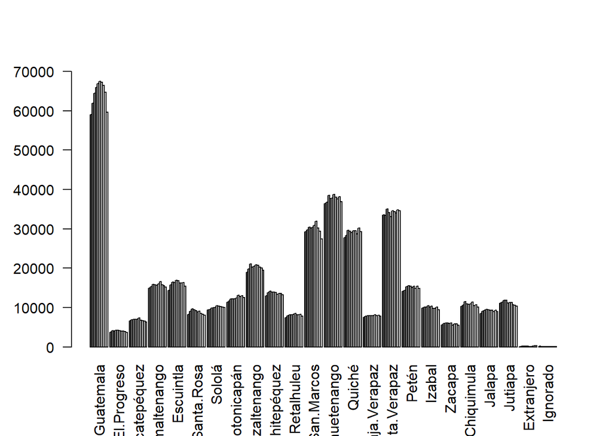

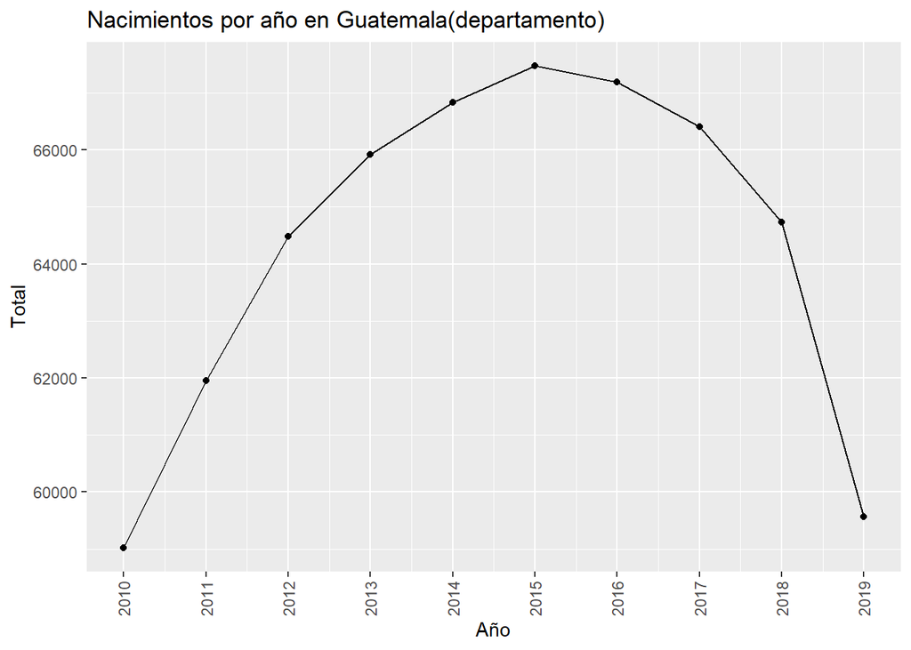

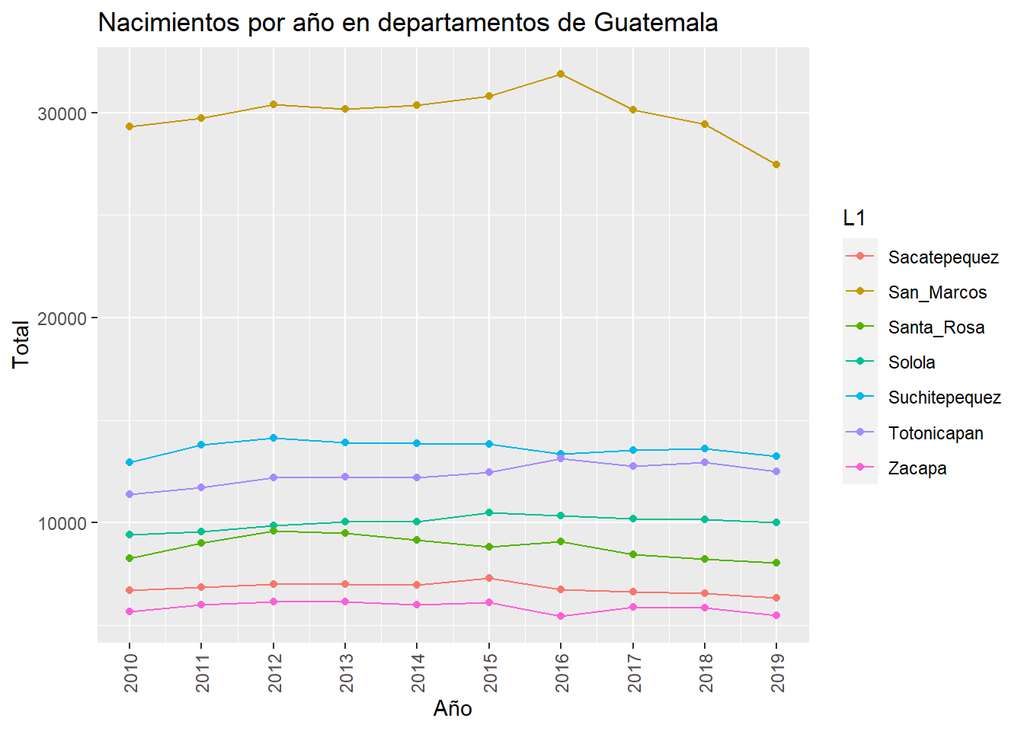

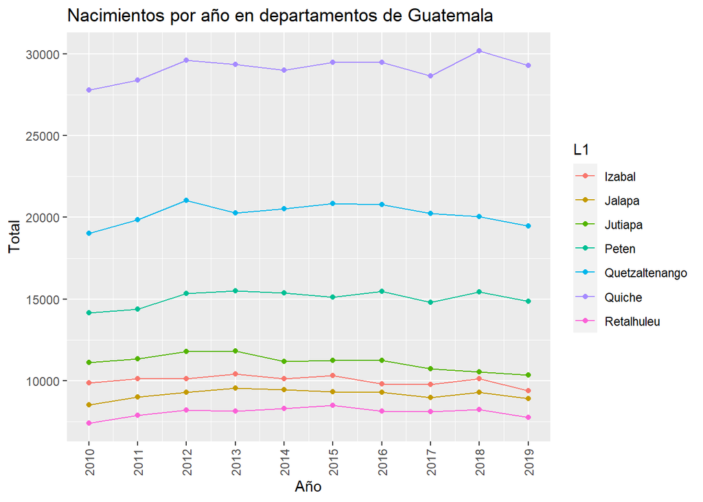

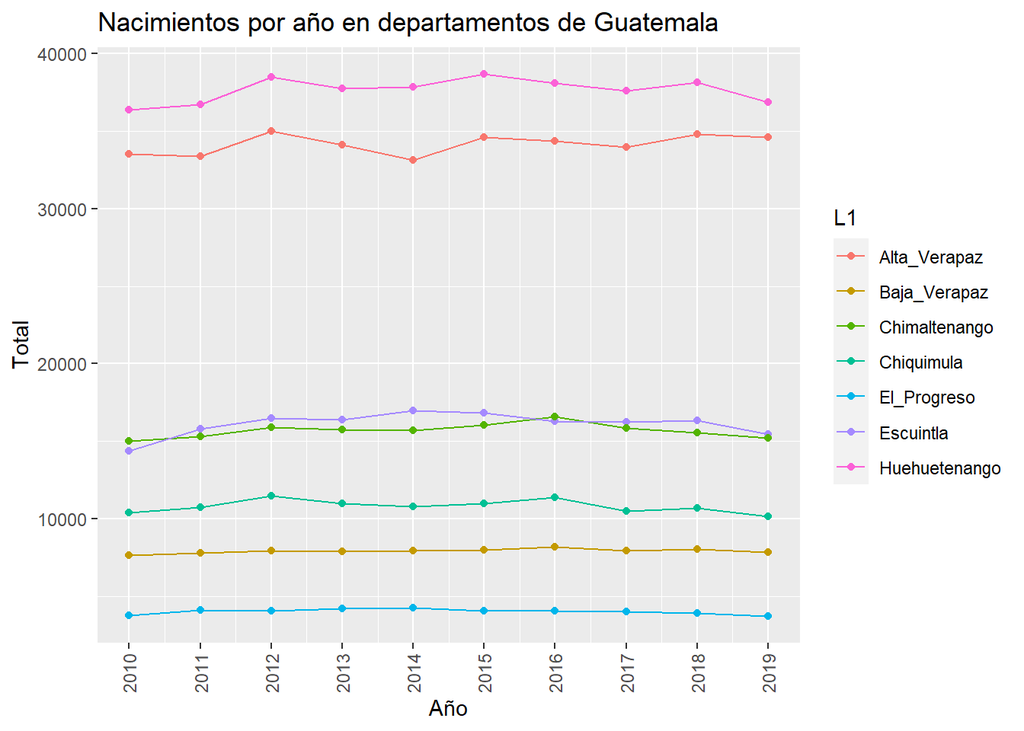

Porcentaje de mortandad por nacimiento en cada departamento:

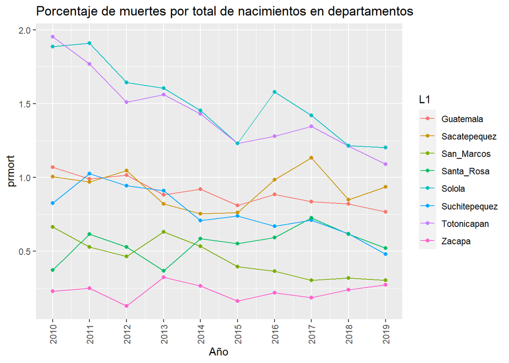

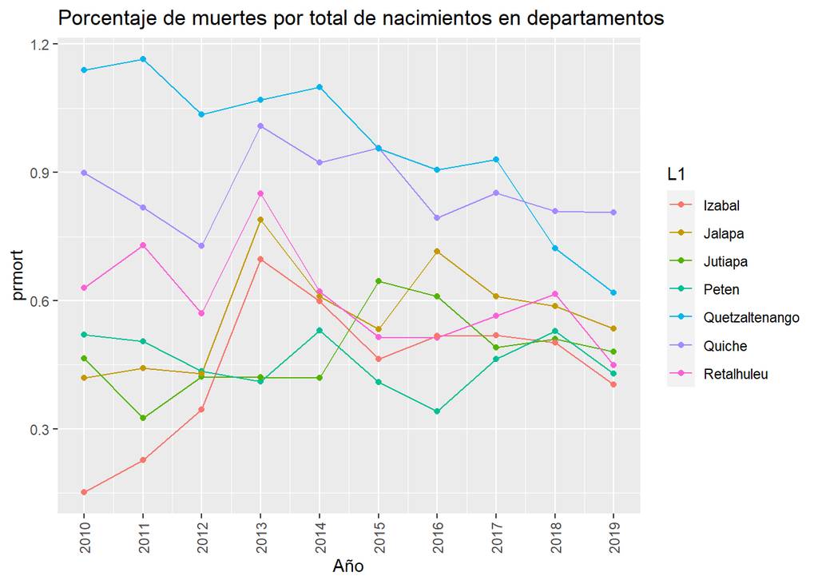

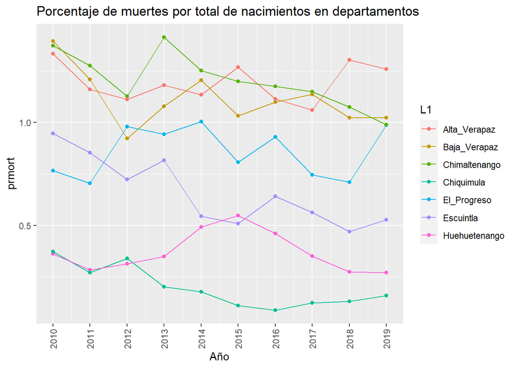

Porcentaje de mujeres solteras por cada anio en cada departamento.

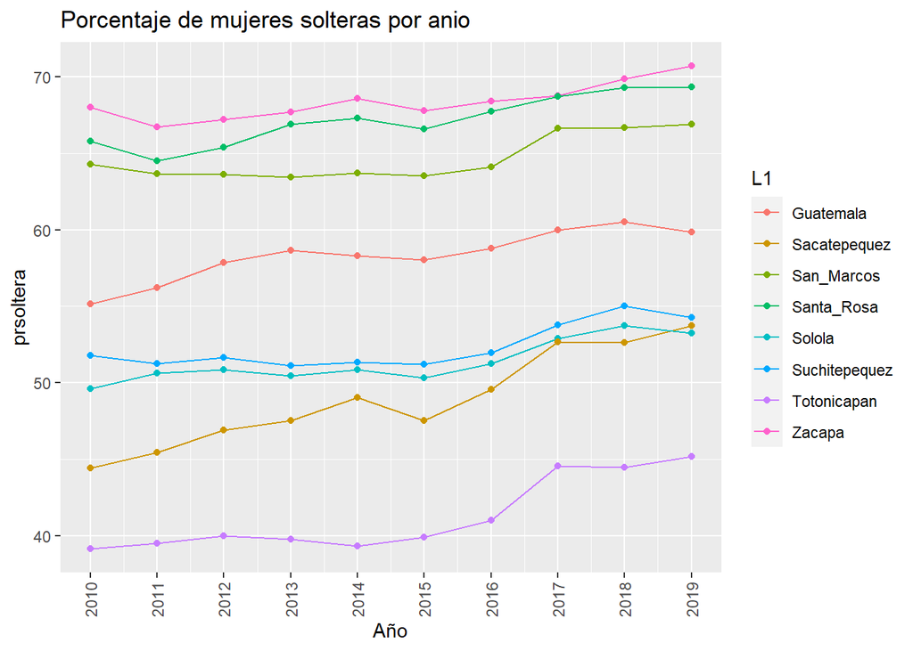

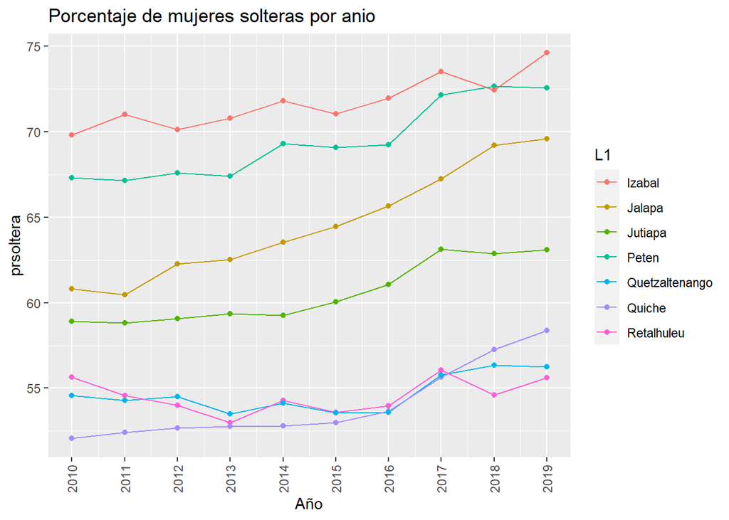

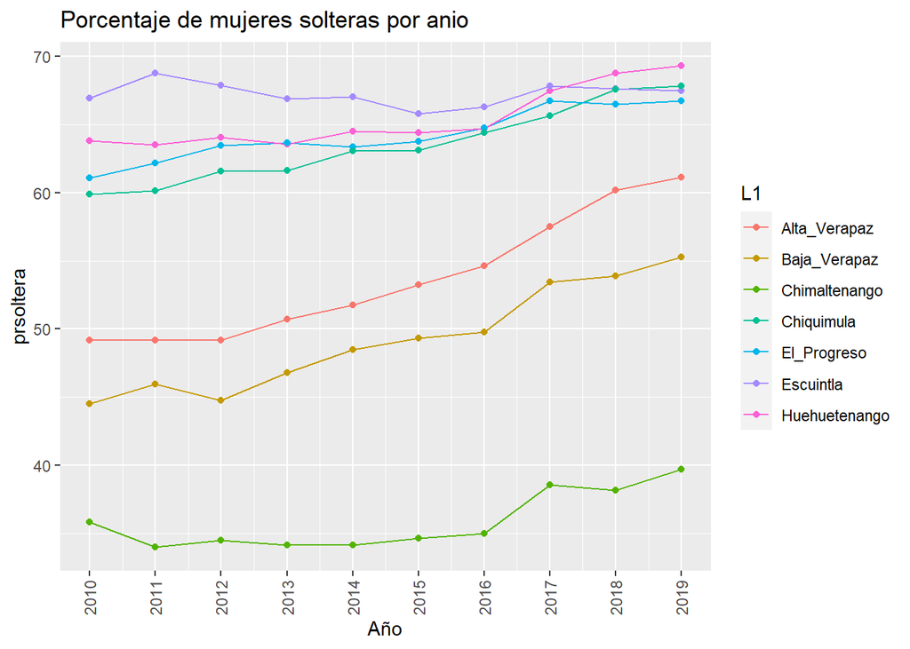

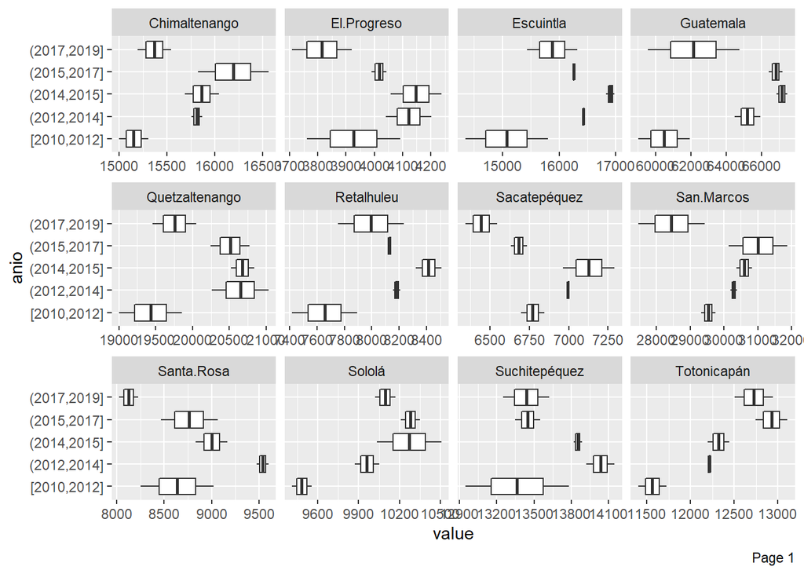

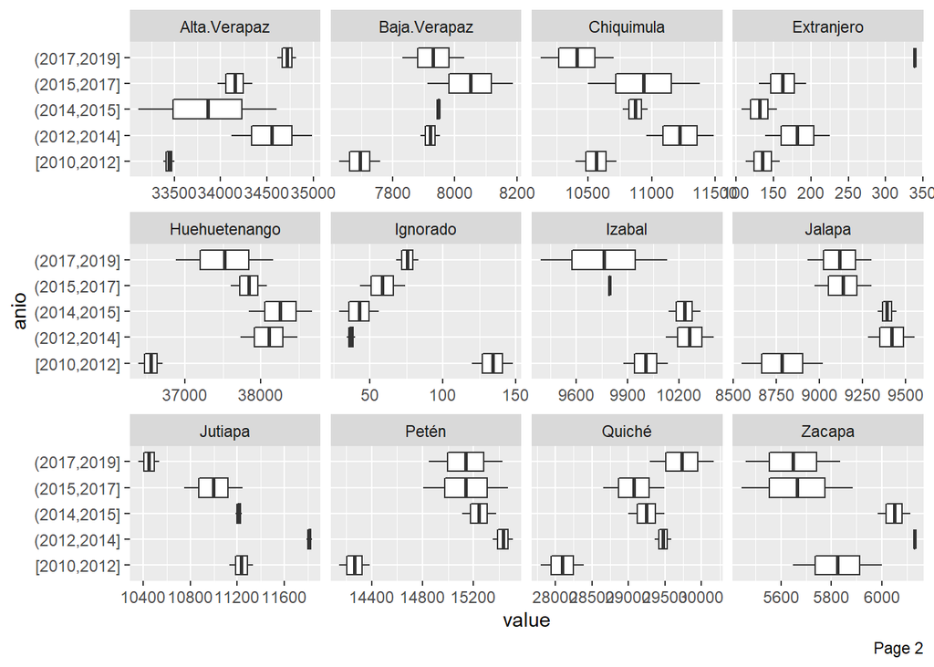

Tambien nos preguntamos como se distribuian los datos en relacion con los nacimientos, el peso del bebe y su departamento de nacimiento. Se obtuvieron los siguientes resultados:

```
## [1] "Todos los departamentos"
```

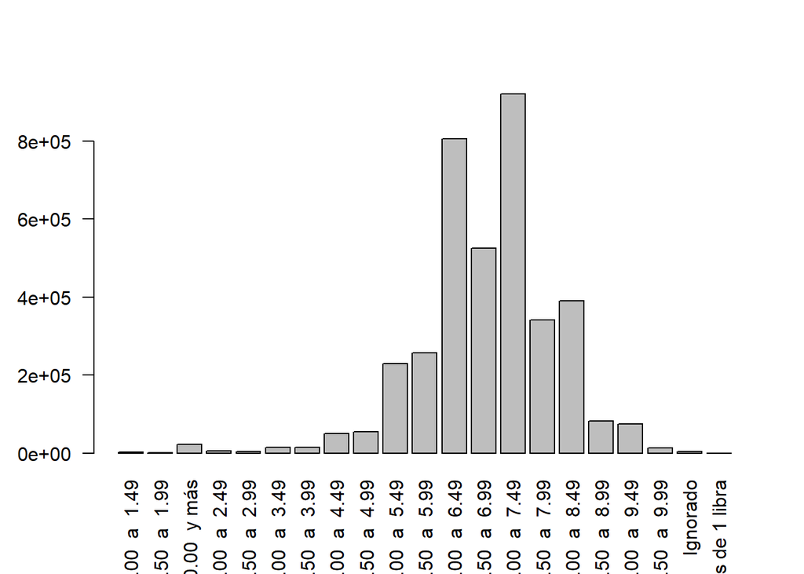

```
## [1] "Guatemala"
```

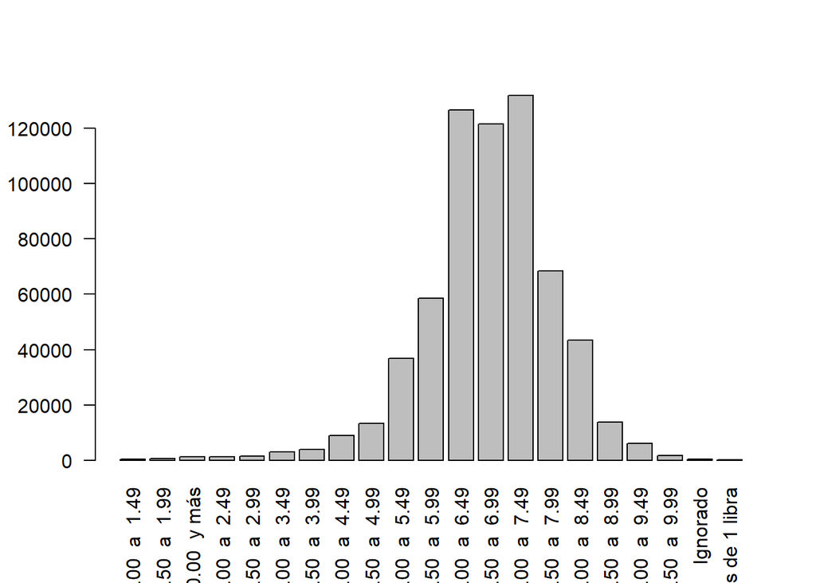

```
## [1] "El Progreso"
```

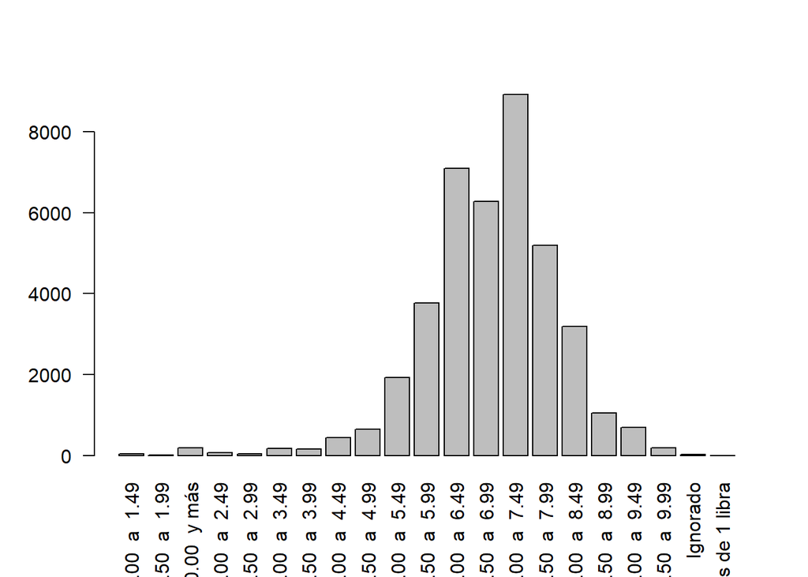

```
## [1] "Sacatepéquez"
```

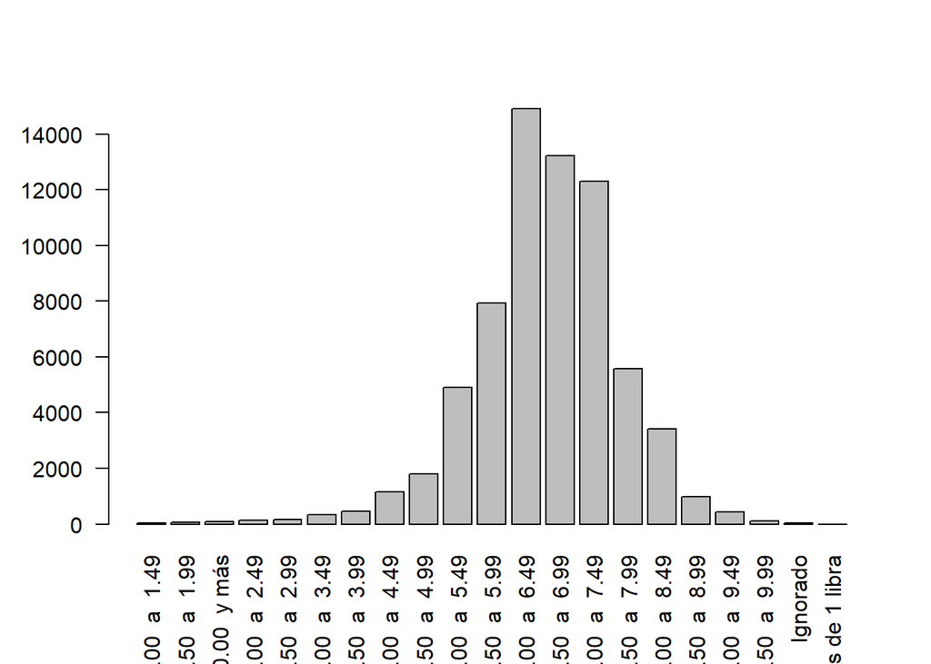

```
## [1] "Chimaltenango"
```

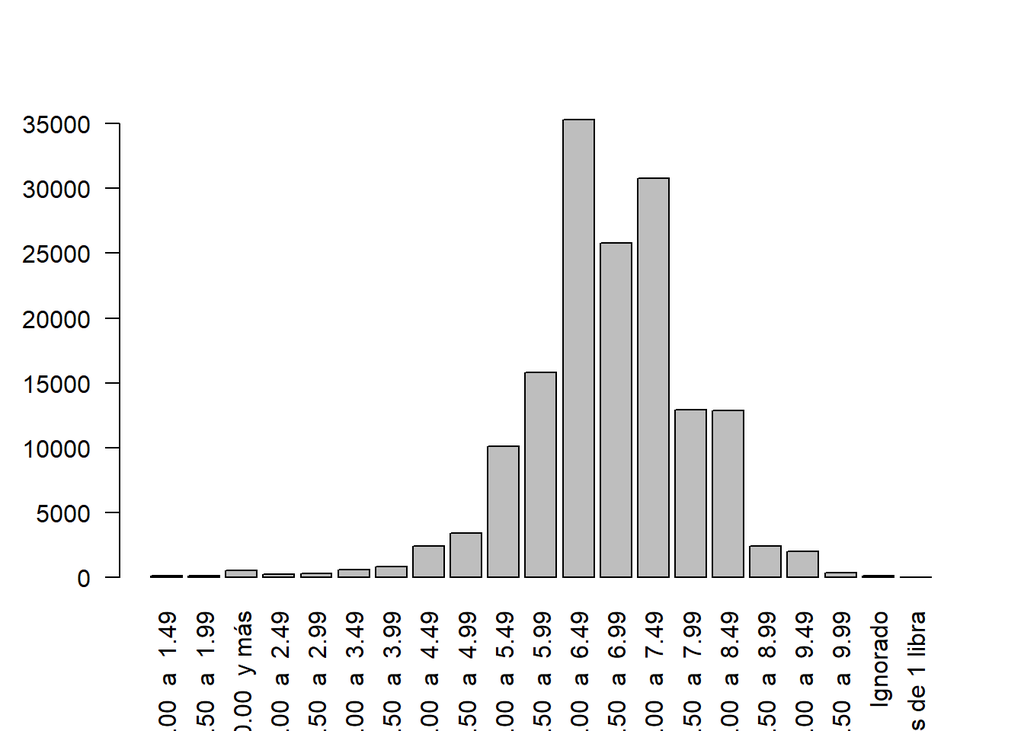

```
## [1] "Escuintla"
```

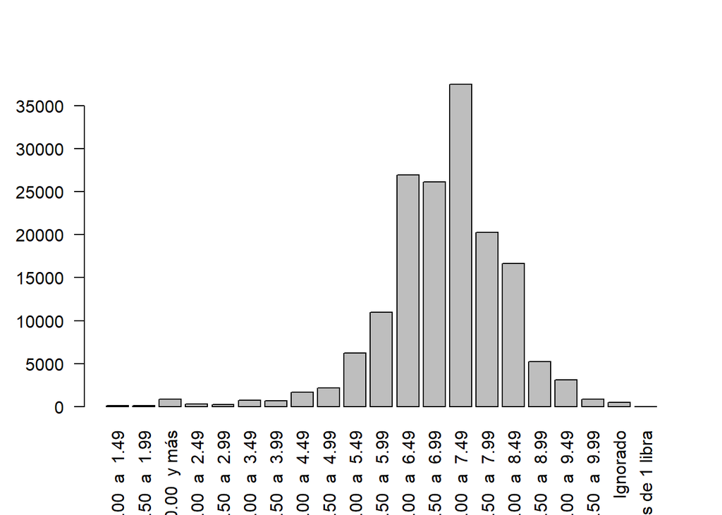

```
## [1] "Santa Rosa"
```

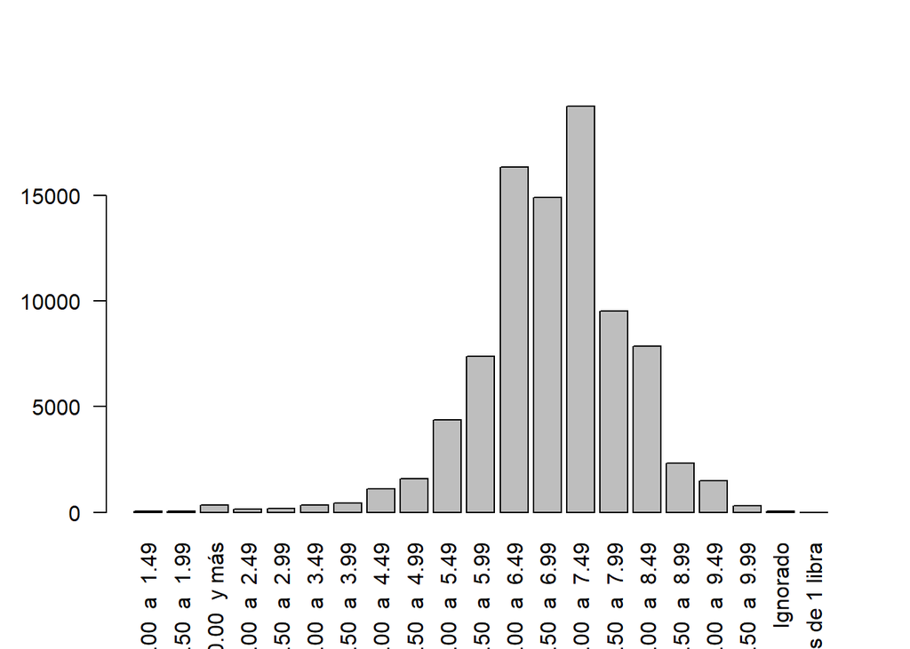

```
## [1] "Sololá"
```

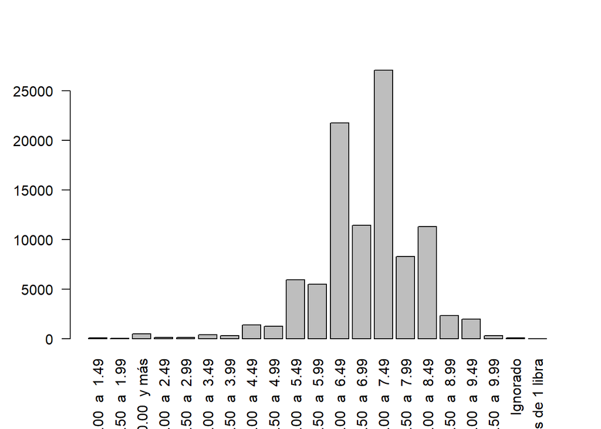

```
## [1] "Totonicapán"
```

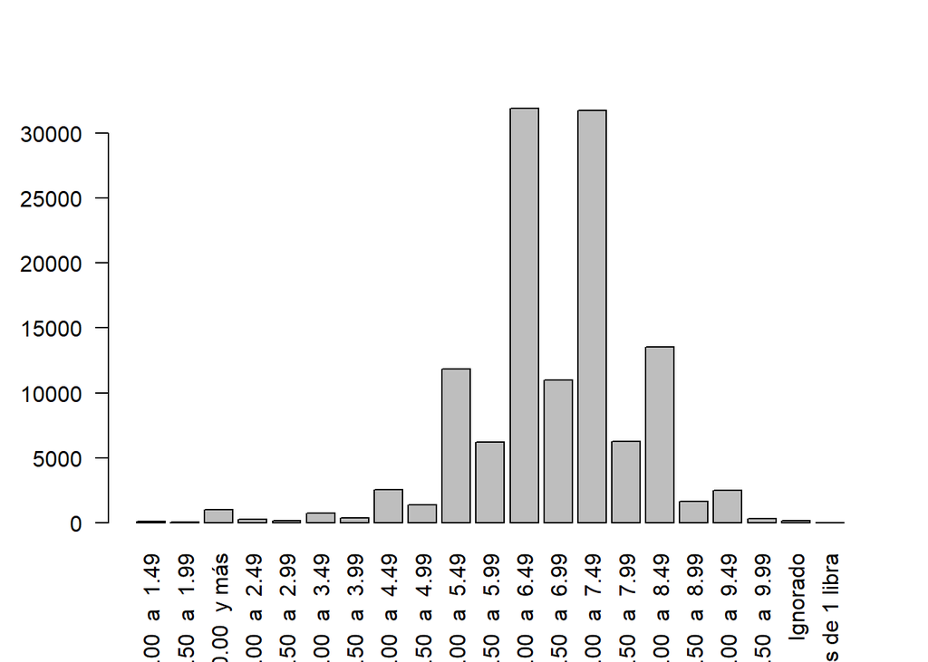

```
## [1] "Quetzaltenango"
```

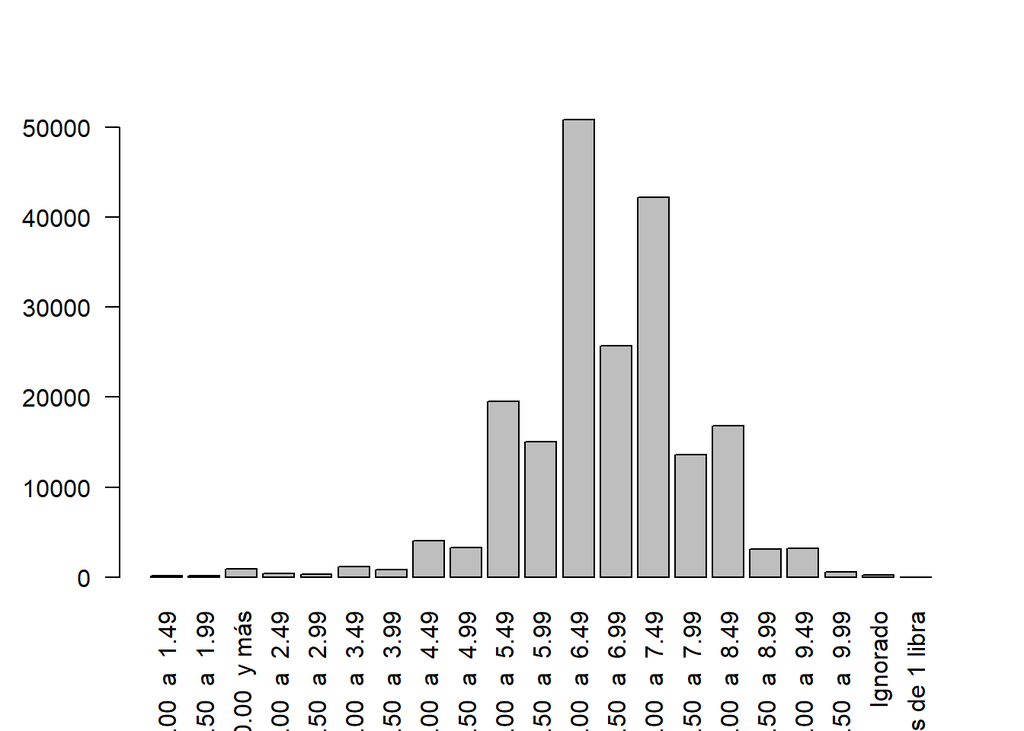

```
## [1] "Suchitepéquez"
```

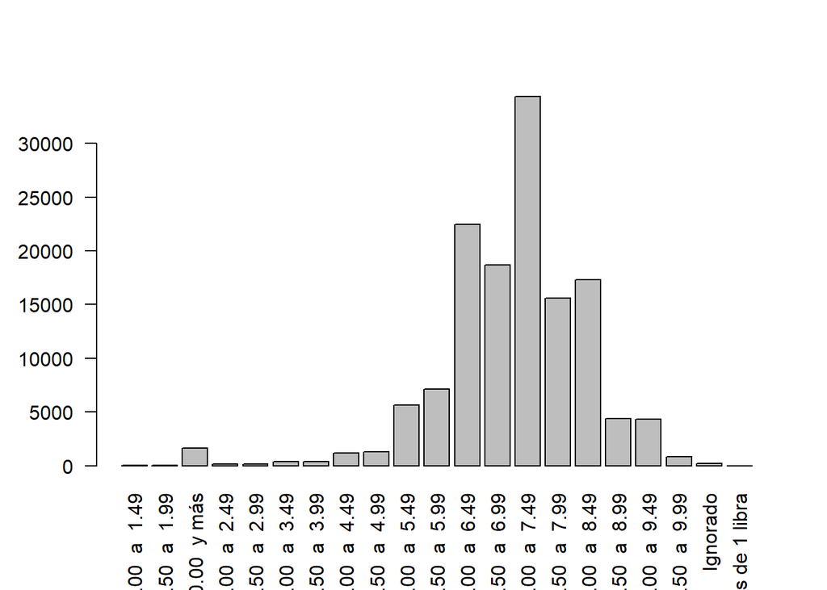

```
## [1] "Retalhuleu"
```

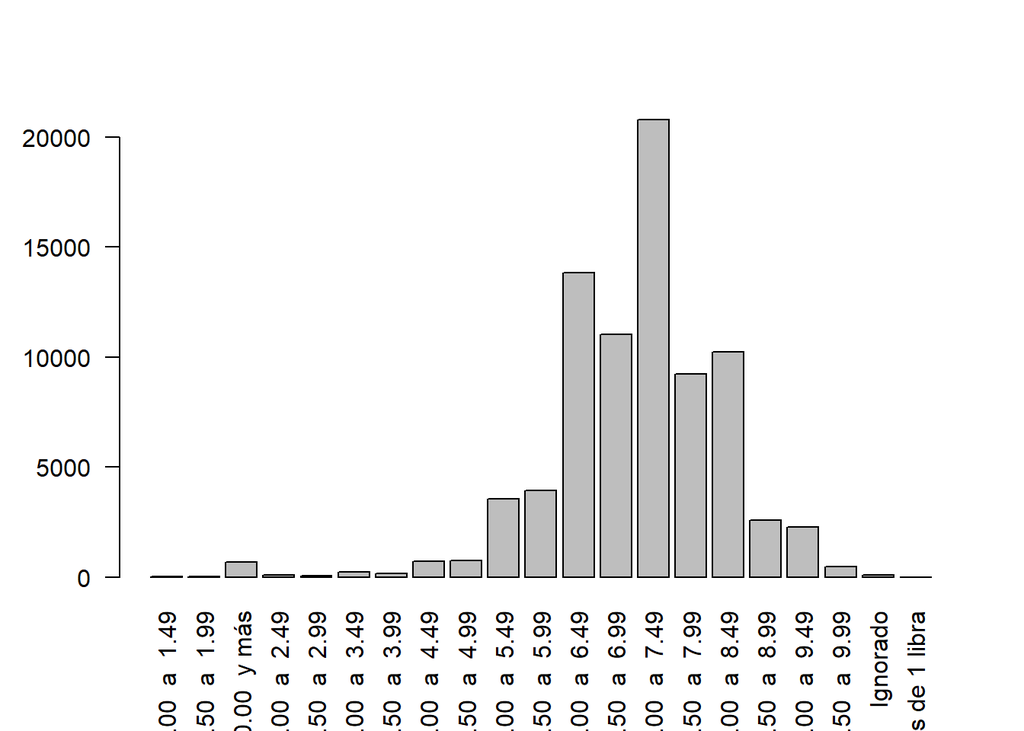

```
## [1] "San Marcos"
```

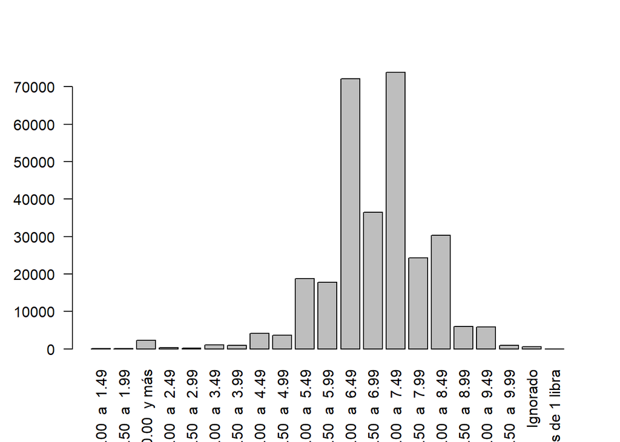

```
## [1] "Huehuetenango"
```

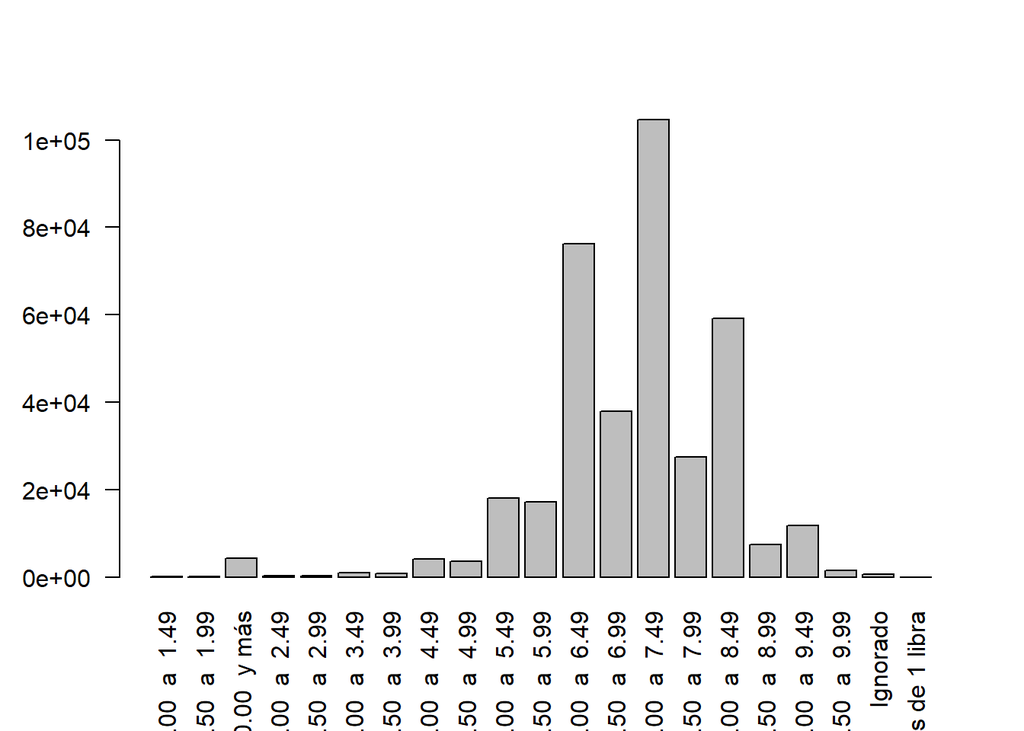

```
## [1] "Quiché"
```

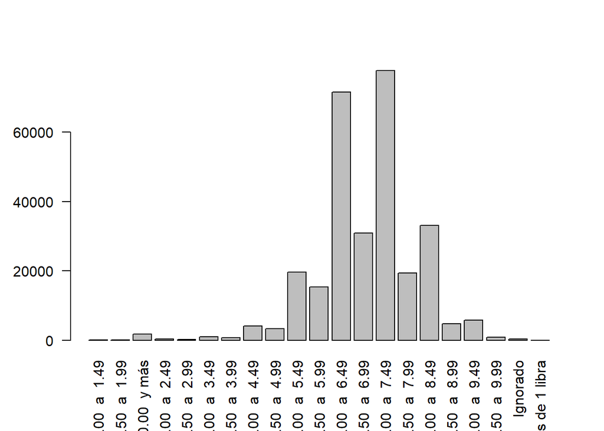

```
## [1] "Baja Verapaz"
```

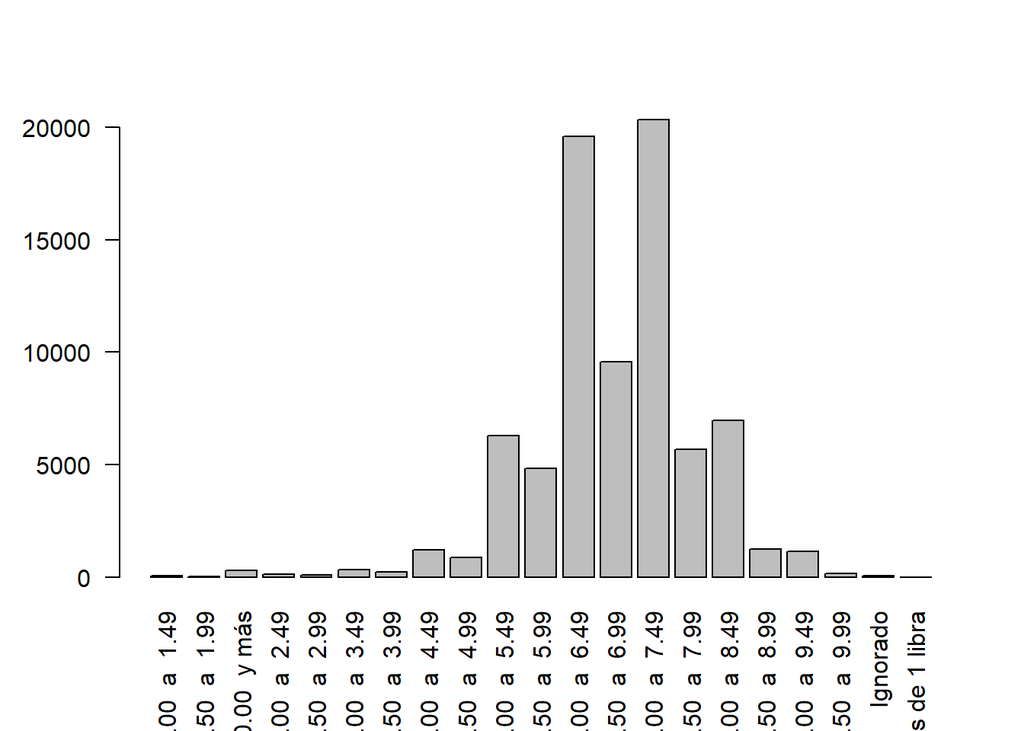

```
## [1] "Alta Verapaz"
```

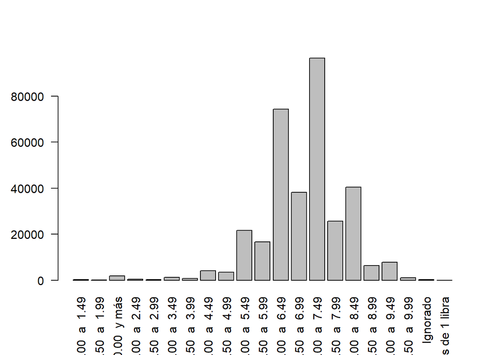

```
## [1] "Petén"
```

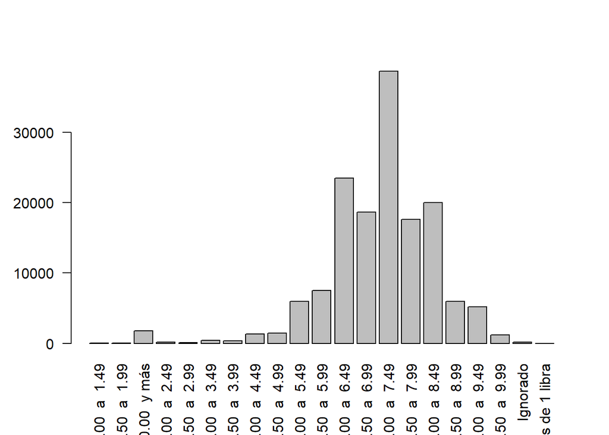

```
## [1] "Izabal"
```